# Stat 361 - Recitation3

Serenay Çakar

2026-03-05

# Methods for Generating Random Variables

We will study a number of methods for generating univariate random variables. The three principal methods are:

1. **Inverse Transform Method**
2. **Acceptance-Rejection Method**
3. **Convolution Method**

All of these methods rely on having a (good) $U(0,1)$ random number generator available, which we assume to be the case.

## 1. Inverse Transform Method

The **inverse transform method** is based on the principle that if $U \sim U(0,1)$, then we can obtain a random variable $X$ from a given distribution by applying the inverse of its cumulative distribution function (CDF).

### Steps:

**1.** Generate $U \sim U(0,1)$.

**2.** Compute $X = F^{-1}(U)$, where $F(x)$ is the CDF of the desired distribution.

**Proposition:** Let U be a Uniform (0,1) random variable for any continuous distribution function F.

$u \sim Unif(0,1)$

$F(x)=u$

Then,

$X=F^{-1}(U)$

Then, the random variable X has distribution F.

### Explanation

Let $F_x$ denote the distribution function of $X=F^{-1}(U)$. Then,

$F_x=P(X \leq x)=P(F^{-1}(U) \leq x)$

Now, since F is a distribution function it follows that $F(x)$ is a monotone increasing function of x and so the inequality $a \leq b$ is equivalent to the inequality $F(a) \leq F(b)$. Hence, from previous equation we see that

$F_x=P(F^{-1}(U) \leq x)$

$F_x=P(X \leq x)=P(F(F^{-1}(U)) \leq F(x))$

We know that $F(F^{-1}(U))=U$. Then,

$F_x=P(X \leq x)=P(U \leq F(x))$

And, since U is Uniform(0,1)

$F_x(x)=F(x)$

The above proposition thus shows that we can generate a random variable X from the continuous distribution function F by generating a random number U and then setting

$X=F^{-1}(U)$

### Example: Exponential Distribution

The CDF of an exponential distribution with rate $\lambda$ is:

$$F(x) = 1 - e^{-\lambda x}, \quad x \geq 0$$

Solving for $x$:

$$x = -\frac{1}{\lambda} \log(1 - U)$$

In R, we can implement this as:

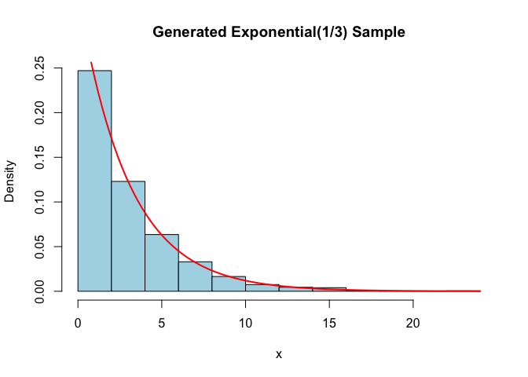

```r
set.seed(123)
lambda <- 1/3
u <- runif(1000)  # Generate 1000 U(0,1) random numbers
x <- -log(1 - u) / lambda  # Apply inverse transform
hist(x, probability = TRUE, main = "Generated Exponential(1/3) Sample", col = "lightblue")
curve(dexp(x, rate = lambda), add = TRUE, col = "red", lwd = 2)
```

# Part 1: Continuous Case

## Question 1

Write a function that will generate and return a random sample of size $n$ from the two-parameter exponential distribution $\text{Exp}(\lambda, \eta)$ for arbitrary $n$, $\lambda$ and $\eta$. The cdf is

$$F(x) = 1 - e^{-\lambda (x - \eta)}, \quad x \geq \eta$$

Generate a large sample from $\text{Exp}(\lambda, \eta)$ and compare the sample quantiles with the theoretical quantiles.

We apply the inverse transformation method to generate a random sample from the two-parameter exponential distribution.

- Generate $U \sim \text{Uniform}(0,1)$.
- Solve for $X$ using the cumulative distribution function:

$$U = 1 - e^{-\lambda (X - \eta)}$$

$$\Rightarrow -\log(1 - U) = \lambda (X - \eta)$$

$$\Rightarrow X = \eta - \frac{1}{\lambda} \log(1 - U).$$

- Since $1 - U \overset{D}{=} U$ when $U \sim \text{Uniform}(0,1)$, we can equivalently generate:

$$X = \eta - \frac{1}{\lambda} \log U.$$

```r
rexp2 <- function(n, lambda, eta) {
  u <- runif(n)
  x <- eta - log(u)/lambda
  return(x)
  }
```

```r
lambda <- 2
eta <- 1
x <- rexp2(1000, lambda, eta)
p <- seq(0.1, 0.9, 0.1)
Q <- -log(1 - p)/lambda + eta # theoretical quantile function (inverse CDF) of two-prmtr exponential dist.
xq <- quantile(x, p)
print(round(rbind(Q, xq), 3))
```

```
##      10%   20%   30%   40%   50%   60%   70%   80%   90%
## Q  1.053 1.112 1.178 1.255 1.347 1.458 1.602 1.805 2.151
## xq 1.062 1.113 1.184 1.262 1.348 1.442 1.599 1.793 2.185
```

## Question 2

The **standard Laplace distribution** has the probability density function:

$$f(x) = \frac{1}{2} e^{-|x|}, \quad x \in \mathbb{R}$$

Use the inverse transform method to generate a random sample of size 1000 from this distribution.

The cumulative distribution function (CDF) of the **standard Laplace distribution** is:

$$F(x) =
\begin{cases}
\frac{1}{2} e^x, & x < 0 \\
1 - \frac{1}{2} e^{-x}, & x \geq 0
\end{cases}$$

Using the **inverse transform method**, we generate $U \sim \text{Uniform}(0,1)$ and solve for $X$:

$$X =
\begin{cases}
\log(2U), & U < 0.5 \\
-\log(2(1 - U)), & U \geq 0.5
\end{cases}$$

## Case 1: If $x < 0$

The probability is given by:

$$P(X \leq x) = \int_{-\infty}^{x} \frac{1}{2} e^{t} dt$$

We can rewrite this integral as:

$$P(X \leq x) = \lim_{c \to -\infty} \int_{c}^{x} \frac{1}{2} e^{t} dt$$

The result of this integral is:

$$P(X \leq x) = \lim_{c \to -\infty} \frac{1}{2} e^{x} \bigg|_{c}^{x} =
\lim_{c \to -\infty} \left( \frac{1}{2} e^{x} - \frac{1}{2} e^{c}
\right)$$

As $c \to -\infty$, the second term vanishes, so we get:

$$P(X \leq x) = \frac{1}{2} e^{x}$$

Thus, the inverse CDF (using the relationship $U = \frac{1}{2} e^{x}$) is:

$$U = \frac{1}{2} e^{x} \quad \Rightarrow \quad x = \ln(2U)$$

Since $x < 0$, we have $0 < U < \frac{1}{2}$, which satisfies the condition.

## Case 2: If $x \geq 0$

The probability is given by:

$$P(X \leq x) = \int_{-\infty}^{0} \frac{1}{2} e^{t} dt + \int_{0}^{x}
\frac{1}{2} e^{-t} dt$$

The result of the first integral is:

$$\int_{-\infty}^{0} \frac{1}{2} e^{t} dt = \frac{1}{2} e^{0} =
\frac{1}{2}$$

The result of the second integral is:

$$\int_{0}^{x} \frac{1}{2} e^{-t} dt = \frac{1}{2} \left( -e^{-x} + e^{0}
\right) = \frac{1}{2} \left( 1 - e^{-x} \right)$$

So the total probability is:

$$P(X \leq x) = \frac{1}{2} + \frac{1}{2} \left( 1 - e^{-x} \right) = 1 -
\frac{1}{2} e^{-x}$$

Thus, using the relationship $U = 1 - \frac{1}{2} e^{-x}$, we get:

$$U = 1 - \frac{1}{2} e^{-x} \quad \Rightarrow \quad x = -\ln(2 - 2U)$$

Since $x \geq 0$, we have $\frac{1}{2} \leq U < 1$, which satisfies the condition.

## Final Expression for $F^{-1}(U)$

Thus, the inverse CDF, $F^{-1}(U)$, is given by:

$$F^{-1}(U) =
\begin{cases}
\ln(2U), & \text{if } U < \frac{1}{2} \\
-\ln(2 - 2U), & \text{if } U \geq \frac{1}{2}
\end{cases}$$

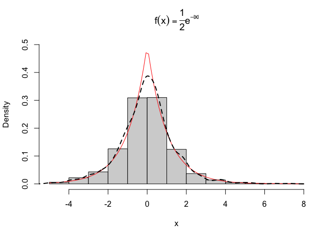

```r
n <- 1000
u <- runif(n)
x.vect <- numeric(n)

# Generate values based on conditions
x.vect <- ifelse(u < 0.5, log(2 * u), -log(2 * (1 - u)))

# Plot histogram with probability density
hist(x.vect, prob = TRUE, ylim = c(0, 0.5), xlab = "x",
     main = expression(f(x) == frac(1, 2) * e^{-abs(x)}))

# Add theoretical density curve
# curve draws a function of x; if add = T it uses x-values on the previous
# plot's x-axis
curve(0.5 * exp(-abs(x)), col = "red", add = TRUE)

# Add density estimate from the generated data
lines(density(x.vect), lty = 2, lwd = 2)
```

## Question 3

The Pareto(a, b) distribution has pdf and cdf as follow:

- The PDF of Pareto Distribution is:

$$f(x)=\frac{a*b^a}{x^{a+1}}, x \geq b > 0, a > 0.$$

- The CDF of Pareto Distribution is given by:

$$F(x)=1-(\frac{b}{x})^a, x \geq b > 0, a > 0.$$

Derive the probability inverse transformation $F^{-1}(U)$ and use the inverse transform method to simulate a random sample from the Pareto(2, 2) distribution. Graph the density histogram of the sample with the Pareto(2, 2) density superimposed for comparison.

To solve for x,

$$u=F(x)=1-(\frac{b}{x})^a , x \ge b >0 , a>0$$

$$x=b*(1-u)^{\frac{-1}{a}}$$

```r
a <- b <- 2
n <- 1000
u <- runif(n)
x <- b * u^(-1/a)
print(summary(x))
```

```
##    Min. 1st Qu.  Median    Mean 3rd Qu.    Max.
##   2.001   2.281   2.813   4.154   4.054 247.429
```

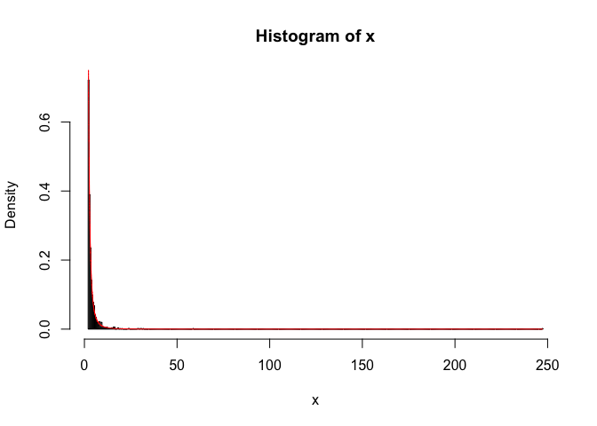

```r
hist(x, breaks = "FD",prob = TRUE) # "FD" (Freedman-Diaconis): Good for data with outliers.
y <- sort(x)
fy <- a * b^a * y^(-(a + 1))
lines(y, fy, col="red")
```

## Question 4

The **Rayleigh density function** is given by:

$$f(x) = \frac{x}{\sigma^2} e^{-x^2 / (2\sigma^2)}, \quad x \geq 0, \quad
\sigma > 0$$

Develop an algorithm to generate random samples from a Rayleigh($\sigma$) distribution.

Generate Rayleigh($\sigma$) samples for several choices of $\sigma$ > 0 and check that the mode of the generated samples is close to the theoretical mode $\sigma$ (check the histogram).

To find the **CDF**, we integrate the density function:

$$F(x) = \int_0^x \frac{t}{\sigma^2} e^{-t^2 / (2\sigma^2)} dt$$

Solving this integral gives:

$$F(x) = 1 - \exp\left(-\frac{x^2}{2\sigma^2}\right), \quad x > 0.$$

We generate random samples using the inverse transform method:

- Generate a **uniform random variable** $U \sim \text{Uniform}(0,1)$.
- Solve for $X$ in terms of $U$:

  $$u = 1 - e^{-x^2 / (2\sigma^2)}$$

  Taking the inverse:

  $$X = F^{-1}(U) = \sigma \sqrt{-2 \log(1 - U)}$$
- Since $U \sim \text{Uniform}(0,1)$ has the same distribution as $1 - U$, we simplify:

  $$X = \sigma \sqrt{-2 \log U}$$

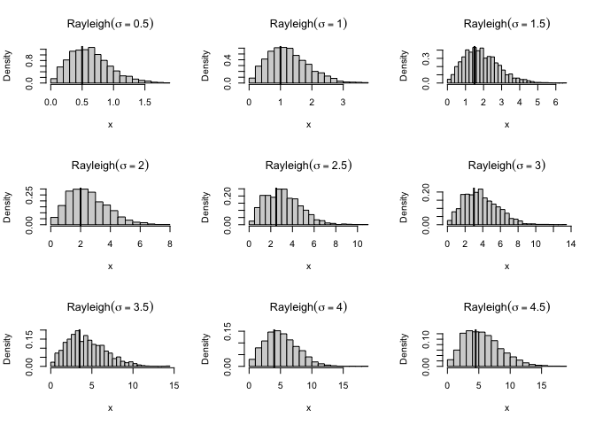

```r
# We have unknown parameter, sigma. Hence, we should run the code for different possible values of this parameter.
n <- 2000
sigma <- seq(0.5, 4.5, length = 9) # Take different values of sigma
par(mfrow = c(3, 3))
for (i in 1:length(sigma)) {
  u <- runif(n)
  x <- sigma[i] * sqrt(-2 * log(u))
  hist(x, breaks = "Scott", prob = TRUE,
     main = bquote("Rayleigh" * (sigma == .(sigma[i]))))
  abline(v = sigma[i], lwd = 2)
}
```

# Part 2: Discrete Case

The inverse transform method can also be applied to **discrete distributions**. If $X$ is a **discrete random variable** with a probability mass function (pmf) given by:

$$P(X_i = x_i) = p_i, \quad x_0 < x_1 < \dots, \quad \sum p_i = 1$$

then the inverse transformation is:

$$X = x_i, \quad \text{if } F(x_{i-1}) < U < F(x_i)$$

where $F(x)$ is the **cumulative distribution function (CDF)**, and $U \sim \text{Uniform}(0,1)$.

## Algorithm

The following steps outline the **inverse transform sampling method** for discrete distributions:

1. Define a **pmf** for $x_i, i = 1, \dots, k$.
2. Generate a **uniform random number** $U \sim \text{Uniform}(0,1)$.
3. If $U \leq p_0$, set $X = x_0$.
4. Else if $U \leq p_0 + p_1$, set $X = x_1$.
5. Else if $U \leq p_0 + p_1 + p_2$, set $X = x_2$.
6. Continue this process until the corresponding value of $X$ is assigned.

This algorithm efficiently generates **random samples** from a discrete probability distribution.

## Question 5

Consider a balanced coin tossing example where P(H) = 0.6. You are tossing that balanced coin 4 times and let the random variable Y is the number of **Heads** occurred.

**a)** Find the pmf of this distribution of Y and from that distribution, generate a random sample of size 1000 by using inverse transformation method.

The distribution of the random variable $Y$ follows a Binomial distribution with parameters $n = 4$ and $p = 0.6$.

The PMF of a Binomial distribution is given by the formula:

$$P(Y = y) = \binom{n}{y} p^y (1-p)^{n-y}, \quad y = 0, 1, 2, \dots, n$$

For $n = 4$ and $p = 0.6$, the PMF table is as follows:

| $y$ | $P(Y = y)$ |
| --- | --- |
| 0 | $\binom{4}{0} (0.6)^0 (0.4)^4 = 0.0256$ |
| 1 | $\binom{4}{1} (0.6)^1 (0.4)^3 = 0.1536$ |
| 2 | $\binom{4}{2} (0.6)^2 (0.4)^2 = 0.3456$ |
| 3 | $\binom{4}{3} (0.6)^3 (0.4)^1 = 0.3456$ |
| 4 | $\binom{4}{4} (0.6)^4 (0.4)^0 = 0.1296$ |

The CDF is the cumulative sum of the PMF up to a certain value of $y$. The formula for the CDF is:

$$F(y) = P(Y \leq y) = \sum_{k=0}^{y} P(Y = k)$$

For $n = 4$ and $p = 0.6$, the CDF is calculated as follows:

$$F(0) = P(Y \leq 0) = P(Y = 0) = 0.0256$$

$$F(1) = P(Y \leq 1) = P(Y = 0) + P(Y = 1) = 0.0256 + 0.1536 = 0.1792$$

$$F(2) = P(Y \leq 2) = P(Y = 0) + P(Y = 1) + P(Y = 2) = 0.0256 + 0.1536 +
0.3456 = 0.5248$$

$$F(3) = P(Y \leq 3) = P(Y = 0) + P(Y = 1) + P(Y = 2) + P(Y = 3) = 0.0256
+ 0.1536 + 0.3456 + 0.3456 = 0.8704$$

$$F(4) = P(Y \leq 4) = P(Y = 0) + P(Y = 1) + P(Y = 2) + P(Y = 3) + P(Y =
4) = 0.0256 + 0.1536 + 0.3456 + 0.3456 + 0.1296 = 1$$

```r
# or use dbinom()
n <- 4
p <- 0.6

k_vals <- 0:n
pmf <- dbinom(k_vals, size = n, prob = p)

data.frame(y = k_vals, P_Y_y = pmf)
```

| y | P_Y_y |
| --- | --- |
| 0 | 0.0256 |
| 1 | 0.1536 |
| 2 | 0.3456 |
| 3 | 0.3456 |
| 4 | 0.1296 |

```r
# Or coompute PMF manually
n <- 4
p <- 0.6
q <- 1 - p

pmf_manual <- c(choose(n, 0) * (p^0) * (q^4),
                choose(n, 1) * (p^1) * (q^3),
                choose(n, 2) * (p^2) * (q^2),
                choose(n, 3) * (p^3) * (q^1),
                choose(n, 4) * (p^4) * (q^0))
pmf_manual
```

```
## [1] 0.0256 0.1536 0.3456 0.3456 0.1296
```

```r
n <- 1000
y <- numeric(n) #create an empty vector
prob <- c(0.0256, 0.1536, 0.3456, 0.3456, 0.1296) # Store the probabilities
i <- 0
set.seed(361)
while( i <= n ){
  u <- runif(1)
  y[i] <- ifelse(u <= prob[1], 0,
                 ifelse(u <= sum(prob[1:2]),1,
                        ifelse(u <= sum(prob[1:3]),2,
                               ifelse(u <= sum(prob[1:4]),3,4))))
  i <- i + 1
  }

# Compare the estimated probabilities with theoretical ones.
rbind(table(y)/n, prob)
```

```
##           0      1      2      3      4
##      0.0330 0.1540 0.3510 0.3350 0.1270
## prob 0.0256 0.1536 0.3456 0.3456 0.1296
```

**b)** Compute the mean and variance of the generated sample and compare the results with theoretical expectation and variance.

```r
#domain of y
d <- seq(0,4)

theoretical.mean = sum(prob*d)
est.mean = mean(y)

theoretical.var = sum(prob*d^2)-(sum(prob*d))^2
est.var = var(y)

result_matrix <- matrix(c(theoretical.mean, est.mean, theoretical.var, est.var),
                       nrow = 2, ncol = 2, byrow = TRUE)

rownames(result_matrix) <- c("Mean", "Variance")
colnames(result_matrix) <- c("Theoretical", "Estimated")
round(result_matrix, 2)
```

```
##          Theoretical Estimated
## Mean            2.40      2.37
## Variance        0.96      0.99
```

## Question 6

A discrete random variable X has probability mass function

| $x$ | 0 | 1 | 2 | 3 | 4 |
| --- | --- | --- | --- | --- | --- |
| $P(X = x)$ | 0.1 | 0.2 | 0.2 | 0.2 | 0.3 |

Use the inverse transform method to generate a random sample of size 1000 from the distribution of X. Construct a relative frequency table and compare the empirical with the theoretical probabilities. Repeat using the R sample function.

```r
# Method 1:
n <- 1000
p <- c(0.1, 0.2, 0.2, 0.2, 0.3)
cdf <- cumsum(p)
x <- numeric(n)

for (i in 1:n){
  x[i] <- sum(runif(1) > cdf)
  }

rbind(table(x)/n, p)
```

```
##       0     1     2     3     4
##   0.091 0.201 0.203 0.204 0.301
## p 0.100 0.200 0.200 0.200 0.300
```

```r
# The relative sample frequencies agree closely with the theoretical probability distribution (p) in the second row.
```

```r
# Repeat using the R sample function.
n <- 1000
p <- c(0.1, 0.2, 0.2, 0.2, 0.3)
x <- sample(0:4, size = n, prob = p, replace = TRUE)
rbind(table(x)/n, p)
```

```
##       0     1     2     3     4
##   0.097 0.208 0.186 0.226 0.283
## p 0.100 0.200 0.200 0.200 0.300
```

```r
# Method 2:

n <- 1000
p <- c(0.1, 0.2, 0.2, 0.2, 0.3)
cdf <- cumsum(p)

# Generate n uniform random values
u <- runif(n)

# Apply the inverse CDF method
x <- sapply(u, function(ui) sum(ui > cdf))

# Compare empirical and theoretical probabilities
rbind(table(x)/n, p)
```

```
##       0     1     2     3     4
##   0.091 0.196 0.212 0.204 0.297
## p 0.100 0.200 0.200 0.200 0.300
```

## Question 7

Let $X$ be a discrete random variable that has the following probability mass function:

$$P(X = 0) = 0.3, \quad P(X = 1) = 0.2, \quad P(X = 2) = 0.5.$$

We want to generate random variables for $X$ using the **discrete inverse transform method** for 100 variates from the desired probability mass function.

**Probability Mass Function (PMF)**

$$p(x) = \begin{cases}
0.3, & x = 0 \\
0.2, & x = 1 \\
0.5, & x = 2
\end{cases}$$

**Cumulative Distribution Function (CDF)**

$$F(x) = \begin{cases}
0, & x < 0 \\
0.3, & 0 \leq x < 1 \\
0.5, & 1 \leq x < 2 \\
1, & x \geq 2
\end{cases}$$

**Simulation using the Discrete Inverse Transform Method**

We generate random variables for $X$ according to the following scheme:

$$X = \begin{cases}
0, & U \leq 0.3 \\
1, & 0.3 < U \leq 0.5 \\
2, & 0.5 < U \leq 1
\end{cases}$$

```r
# 1st way

n <- 1000 # sample size

x <- numeric(n)

prob <- c(0.3, 0.2, 0.5) # store the probabilities

set.seed(361)
for (i in 1:n){
  u <- runif(1)
  if(u <= prob[1]){
    x[i] <- 0}
  else if(u <= sum(prob[1:2])){
      x[i] <- 1}
  else{
        x[i] <- 2}
}
```

```r
# Compute relative frequencies of each x and compare with theoretical ones
rbind(table(x)/n, prob)
```

```
##          0     1     2
##      0.318 0.197 0.485
## prob 0.300 0.200 0.500
```

```r
# 2nd way
set.seed(361)
n <- 1000
U <- runif(n)

# Apply inverse transform sampling
X <- ifelse(U <= 0.3, 0, ifelse(U <= 0.5, 1, 2))
rbind(table(X)/n, prob)
```

```
##          0     1     2
##      0.318 0.197 0.485
## prob 0.300 0.200 0.500
```

## Advantages of the Inverse Transform Method

There are two principal advantages to the inverse transform method:

1. **Monotonicity**: We have already seen how this can be useful.
2. **1-to-1 Mapping**: The method is 1-to-1, i.e., one `U(0,1)` variable produces one `X` variable. This property can be useful for some variance reduction techniques.

## Disadvantages of the Inverse Transform Method

The principal disadvantage of the inverse transform method is that $F^{-1}(x)$ may not always be computable.

For example, suppose $X \sim N(0,1)$. Then:

$$F_X(x) = \int_{-\infty}^{x}
\frac{1}{\sqrt{2\pi}} e^{-z^2/2} dz$$

so that we cannot even express $F_X$ in closed form.

Even if $F_X$ is available in closed form, it may not be possible to find $F^{-1}(x)$ in closed form. For example, suppose:

$$F_X(x) = \frac{x^5(1+x)^3}{8}, \quad 0
\leq x \leq 1.$$

Then we cannot compute $F^{-1}(x)$. One possible solution to these problems is to find $F^{-1}(x)$ numerically.

# Exercise-1:

Let $X$ have a standard Cauchy distribution with the cumulative distribution function:

$$F_X(x) = \frac{1}{\pi} \arctan(x) + \frac{1}{2}$$

Assuming $U \sim \text{Uniform}(0,1)$, explain how to generate $X$ using the inverse transform method.

Then, use this result to:

1. Generate 1000 samples of $X$.
2. Compute the sample mean.
3. Repeat the experiment 100 times.

What do you observe and why?

# Exercise-2:

Use the inverse transformation method to generate a random variable having the cumulative distribution function:

$$F(x) = \frac{x^2 + x}{2}, \quad 0 \leq x \leq 1$$

# Exercise-3:

Let the random variable X have the following pmf

$$P(X=x)=\frac{x^2}{40}, \space \space \space if \space x=-4,-2,2,4$$

Write a function to generate n random numbers from the given distribution by using inverse transform method. Run the function n=10000 times and compare mean and variance of the generated sample with theoretical expectation and variance.

# Exercise-4:

Using the inverse transform method, write an R function to generate a random sample of observations from the following probability density function (PDF):

$$f_X(x) =
\begin{cases}
x & \text{if } 0 \leq x < 1 \\
2 - x & \text{if } 1 \leq x \leq 2
\end{cases}$$

To test your R function, plot a histogram of 10,000 random numbers generated from this distribution together with the density function given in the question.

| Office hour: Monday, 13.40-14.30 |
| --- |
| Room No: 234 |